# INN_Learner_Notebook_Full_code_version

#### Loss Function Plot

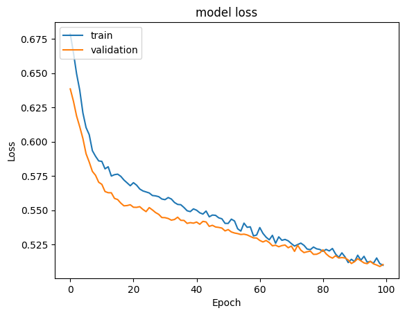

```python
#Plotting Train Loss vs Validation Loss
plt.plot(history_5.history['loss'])
plt.plot(history_5.history['val_loss'])
plt.title('model loss')
plt.ylabel('Loss')
plt.xlabel('Epoch')
plt.legend(['train', 'validation'], loc='upper left')
plt.show()
```

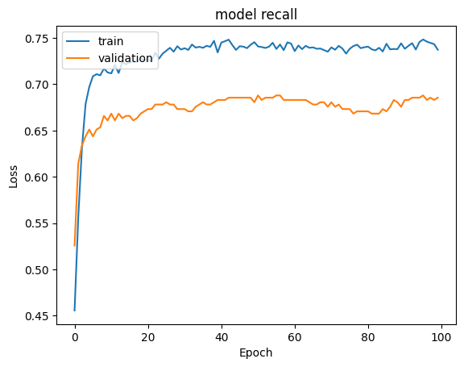

```python
#Plotting Train recall vs Validation recall
plt.plot(history_5.history['recall'])
plt.plot(history_5.history['val_recall'])
plt.title('model recall')
plt.ylabel('Loss')
plt.xlabel('Epoch')
plt.legend(['train', 'validation'], loc='upper left')
plt.show()
```

```python
y_train_pred_5 = model_5.predict(X_train_smote)
#Predicting the results using 0.5 as the threshold
y_train_pred_5 = (y_train_pred_5 > 0.5)
y_train_pred_5
```

```
299/299 ━━━━━━━━━━━━━━━━━━━━ 0s 912us/step
```

```
array([[ True],
       [ True],
       [ True],
       ...,
       [ True],
       [False],
       [ True]])
```

```python
y_val_pred_5 = model_5.predict(X_val)
#Predicting the results using 0.5 as the threshold.
y_val_pred_5 = (y_val_pred_5 > 0.5)
y_val_pred_5
```

```
63/63 ━━━━━━━━━━━━━━━━━━━━ 0s 788us/step
```

```
array([[False],
       [False],
       [ True],
       ...,
       [False],
       [False],
       [ True]])
```

```python
model_name = "NN with SMOTE,Adam & Dropout"

train_metric_df.loc[model_name] = recall_score(y_train_smote,y_train_pred_5)
valid_metric_df.loc[model_name] = recall_score(y_val,y_val_pred_5)
```

#### Classification Report

```python
cr=classification_report(y_train_smote,y_train_pred_5)
print(cr)
```

```
              precision    recall  f1-score   support

         0.0       0.76      0.78      0.77      4777
         1.0       0.78      0.75      0.76      4777

    accuracy                           0.77      9554
   macro avg       0.77      0.77      0.77      9554
weighted avg       0.77      0.77      0.77      9554
```

```python
cr=classification_report(y_val,y_val_pred_5)
print(cr)
```

```
              precision    recall  f1-score   support

         0.0       0.91      0.78      0.84      1593
         1.0       0.45      0.69      0.54       407

    accuracy                           0.76      2000
   macro avg       0.68      0.73      0.69      2000
weighted avg       0.81      0.76      0.78      2000
```

#### Confusion Matrix

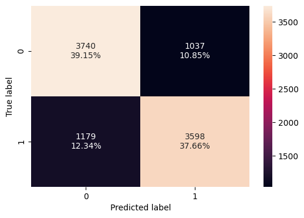

```python
#Calculating the confusion matrix
make_confusion_matrix(y_train_smote, y_train_pred_5)
```

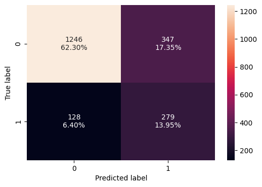

```python
#Calculating the confusion matrix
make_confusion_matrix(y_val,y_val_pred_5)
```

## Model Performance Comparison and Final Model Selection

```python
print("Training performance comparison")
train_metric_df
```

```
Training performance comparison
```

|  | recall |
| --- | --- |
| NN with SGD | 0.221586 |
| NN with Adam | 0.617334 |
| NN with Adam & Dropout | 0.504497 |
| NN with SMOTE & SGD | 0.742307 |
| NN with SMOTE & Adam | 0.901193 |
| NN with SMOTE,Adam & Dropout | 0.753192 |

```python
print("Validation set performance comparison")
valid_metric_df
```

```
Validation set performance comparison
```

|  | recall |
| --- | --- |
| NN with SGD | 0.196560 |
| NN with Adam | 0.447174 |
| NN with Adam & Dropout | 0.452088 |
| NN with SMOTE & SGD | 0.690418 |
| NN with SMOTE & Adam | 0.737101 |
| NN with SMOTE,Adam & Dropout | 0.685504 |

```python
train_metric_df-valid_metric_df
```

|  | recall |
| --- | --- |
| NN with SGD | 0.025026 |
| NN with Adam | 0.170160 |
| NN with Adam & Dropout | 0.052409 |
| NN with SMOTE & SGD | 0.051889 |
| NN with SMOTE & Adam | 0.164092 |
| NN with SMOTE,Adam & Dropout | 0.067689 |

#### Observation

- From the above models, the best performing model is the Neural Network with SMOTE and Adam Optimizer. It has higher train and validation recall scores.

#### Conclusion

- The model_4 is the best performing model.NN with SMOTE & Adam Optimizer.

```python
X_test = np.asarray(X_test).astype(np.float32)
y_test_pred_4f = model_4.predict(X_test)
y_test_pred_4f = (y_test_pred_4f > 0.5)
print(y_test_pred_4f)
```

```
63/63 ━━━━━━━━━━━━━━━━━━━━ 0s 780us/step
[[False]
 [False]
 [False]
 ...
 [ True]
 [False]
 [False]]
```

```python
#lets print classification report
cr=classification_report(y_test, y_test_pred_4f)
print(cr)
```

```
              precision    recall  f1-score   support

           0       0.91      0.78      0.84      1593
           1       0.45      0.71      0.55       407

    accuracy                           0.76      2000
   macro avg       0.68      0.74      0.69      2000
weighted avg       0.82      0.76      0.78      2000
```

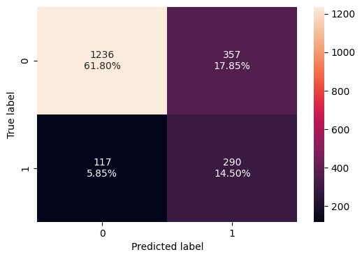

```python
#Calculating the confusion matrix
make_confusion_matrix(y_test,y_test_pred_4f)
```

## Actionable Insights and Business Recommendations

- The older customers are churning at more than the younger ones alluding to a difference in service preference in the age categories. The bank may need to review its target market or review the strategy for retention between the different age groups. The older age group may be aspiring with more benefits or rewards to suit their lifestyle. The older age group have better income and credit history will be a great revenue stream for the bank.
- About the tenure, the clients on either end (spent little time with the bank or a lot of time with the bank) are more likely to churn compared to those that are of average tenure. Worryingly, the bank is losing customers with significant bank balances which are likely to hit their available capital for lending.
- The proportion of female customers churning is also greater than that of male customers. Interestingly, the majority of the customers that churned are those with credit cards. Given that majority of the customers have credit cards could prove this to be just a coincidence.
- Unsurprisingly the inactive members have a greater churn. Worryingly is that the overall proportion of inactive members is quite high suggesting that the bank may need a program implemented to turn this group into active customers as this will have a positive impact on the customer churn.

Power Ahead